# Title: WES_237A_assignment1_report

# PID: A69028485

# Name: William Wei

# GitHub username: William Lien Chin Wei

# Email (registered with GitHub): williams19834812@gmail.com

# Video demonstration of your working code on Youtube: https://youtu.be/4IpPtxGzrf8

# code uploaded under directory "assignment_1" under the repo

[figure not shown]

# Assignments Rubric checklist

($\textbf{Done}$) Report Submitted?  
($\textbf{Done}$) Video Uploaded?  
($\textbf{Done}$) Code Pushed to Github?  
($\textbf{Yes}$) Does the video demonstration show correct execution?  
($\textbf{Yes}$) Is the submitted code correct?  
($\textbf{Well-done}$) How well does the report outlines the design of the code?  
($\textbf{Yes in youtube video}$))How well does the report describe the results?  
($\textbf{Yes}$) Does the Report detail the student's grasp on the goals/objectives of the assignment?

Schematic from https://discuss.pynq.io/t/pynq-z2-pinout/4256/5 (Last visited on Jan 13, 2024)

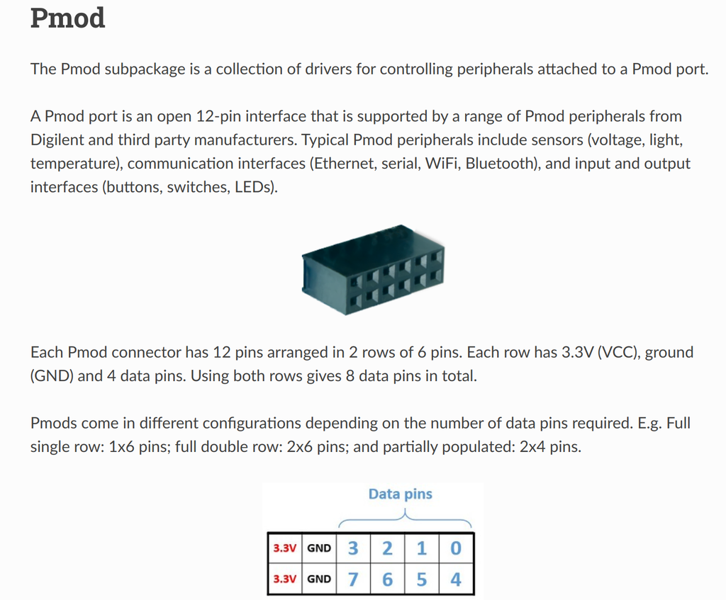

```python
# The ‘-’ pin is connected to ground.
'''
Use the gpio.ipynb from lab as a starting point. Add a C++
function to reset all the GPIO pins on the chosen PMOD
'''

from pynq.overlays.base import BaseOverlay
import time
from datetime import datetime
```

```python
base = BaseOverlay("base.bit")
```

# 1. Use the gpio.ipynb from lab as a starting point. Add a C++ function to reset all the GPIO pins on the chosen PMOD.

```python
%%microblaze base.PMODA

#include "gpio.h"
#include "pyprintf.h"

//Function to turn on/off a selected pin of PMODB
void write_gpio(unsigned int pin, unsigned int val){
    if (val > 1){
        pyprintf("pin value must be 0 or 1");
    }
    gpio pin_out = gpio_open(pin);
    gpio_set_direction(pin_out, GPIO_OUT);
    gpio_write(pin_out, val);
}

//Function to read the value of a selected pin of PMODB
unsigned int read_gpio(unsigned int pin){
    gpio pin_in = gpio_open(pin);
    gpio_set_direction(pin_in, GPIO_IN);
    return gpio_read(pin_in);
}
```

# Test RGB settings for LED

```python
# (R,G,B) = (1,0,0)
write_gpio(3, 1) #R
write_gpio(2, 0) #G
write_gpio(1, 0) #B
time.sleep(3)
```

```python
# (R,G,B) = (0,1,0)
write_gpio(3, 0) #R
write_gpio(2, 1) #G
write_gpio(1, 0) #B
time.sleep(3)
```

```python
# (R,G,B) = (0,0,1)
write_gpio(3, 0) #R
write_gpio(2, 0) #G
write_gpio(1, 1) #B
time.sleep(3)
```

```python
def setAllOff():
    write_gpio(3, 0)
    write_gpio(2, 0)
    write_gpio(1, 0)
```

```python
setAllOff()
time.sleep(3)
```

# 2. Write a Python3 cell that emulates a PWM (for a chosen frequency and duty cycle) on one of the PMOD GPIO pins.

For example, PMODB PIN3 needs to turn on for duty_cycle percent of the square wave frequency and off for the rest of the square wave. It may not be possible to achieve exactly 0% or 100% so be sure to add necessary code for those corner cases.

```python
# Pulse Width Modulation
def runPWM(color, f, dc):
    T = 1/f
    maxCnt = int(5 / T) # number of period for 20 sec

    rgb = {'r': [1,0,0],
           'g': [0,1,0],
           'b': [0,0,1]
          }
    #print(rgb[color][0])
    r, g, b = rgb[color][0], rgb[color][1], rgb[color][2]
    print(r, g, b, T, maxCnt, int(maxCnt*T))

    cnt = 0
    while (cnt<maxCnt):
        cnt+=1
        if r == 1:
            write_gpio(3, 1)
            time.sleep(T * dc)
            write_gpio(3, 0)
            time.sleep(T * (1-dc))

        if g == 1:
            write_gpio(2, 1)
            time.sleep(T * dc)
            write_gpio(2, 0)
            time.sleep(T * (1-dc))

        if b == 1:
            write_gpio(1, 1)
            time.sleep(T * dc)
            write_gpio(1, 0)
            time.sleep(T * (1-dc))


    print('done, LED are off...')
    setAllOff()
```

# 3. Find the optimal PWM frequency, such that the physical flashing phenonmenon will not be perceived visually;

# The optimal PWM frequency I found is 100 Hz using duty cycles at 0.1, respectively

```python
setAllOff()
color, f, dc = 'r', 100, 0.1  # dc: duty cycle (%); f: frequency (Hz)
runPWM(color, f, dc)
time.sleep(3)
setAllOff()
```

```
1 0 0 0.01 500 5
done, LED are off...
```

# 4. Achieve the visually perceived 100%, 75%, 50% and 25% of full LED brightness by adjusting the duty cycle;

# 5. Varying the duty cycles and approximate the corresponding LED brightness (in the unit of %).

To the end, plot and explain the approximate relationship of % brightness versus duty cycle. While working on this task, feel free to check out the $\textbf{Weber-Fechner law}$. For light perception, this law describe the observation that the our eyes perceive light in a non-linear way.

# Weber-Fechner law (From Bard AI)

In essence, the Weber-Fechner law states that the Just Noticeable Difference ($\textbf{JND}$), the smallest change in a stimulus that can be perceived, is proportional to the original stimulus intensity. $\textbf{This means that for a larger initial stimulus, a bigger change is needed to perceive a difference.}$

# Human eyes most sensitively respond to green color, peaking around 555nm. (https://colors.dopely.top/inside-colors/the-most-visible-colors-for-human-eyes/). Therefore, the following trials went with green.

# try various dc, e.g., dc = 0.05, 0.2, 0.5, and 0.99

A plot of perceived brightness (relative to 100% duty cycle) vs. duty cycle and an explanation of the data is plottd as shown below. Be sure to title your plot and label your axes.

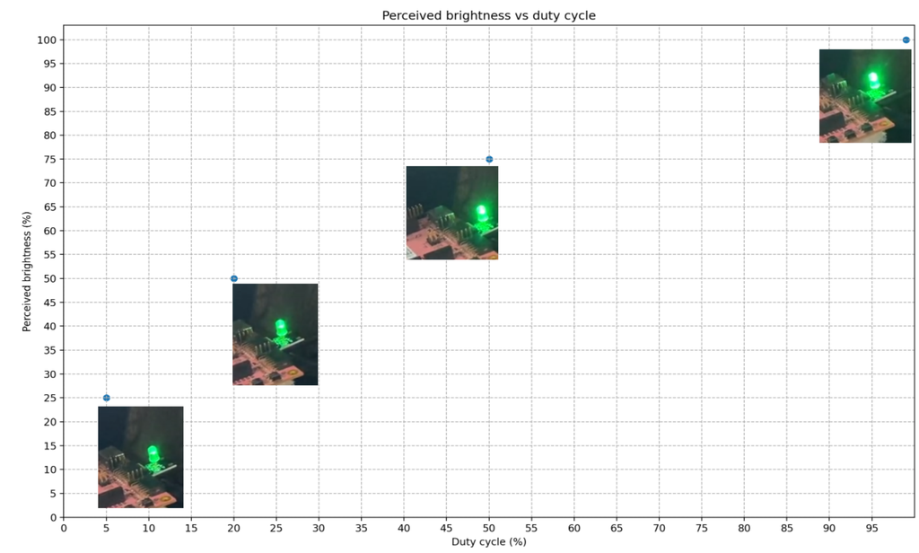

## dc = 0.05 or 5%

```python
#base = BaseOverlay("base.bit")
```

```python
%%microblaze base.PMODA

#include "gpio.h"
#include "pyprintf.h"

//Function to turn on/off a selected pin of PMODB
void write_gpio(unsigned int pin, unsigned int val){
    if (val > 1){
        pyprintf("pin value must be 0 or 1");
    }
    gpio pin_out = gpio_open(pin);
    gpio_set_direction(pin_out, GPIO_OUT);
    gpio_write(pin_out, val);
}

//Function to read the value of a selected pin of PMODB
unsigned int read_gpio(unsigned int pin){
    gpio pin_in = gpio_open(pin);
    gpio_set_direction(pin_in, GPIO_IN);
    return gpio_read(pin_in);
}
```

```python
setAllOff()
color, f, dc = 'g', 100, 0.05  # dc: duty cycle (%); f: frequency (Hz)
print(f'Testing for dc={dc}...')
runPWM(color, f, dc)
setAllOff()
time.sleep(3)
```

```
Testing for dc=0.05...
0 1 0 0.01 500 5
done, LED are off...
```

## dc = 0.2 or 20%

```python
#base = BaseOverlay("base.bit")
```

```python
%%microblaze base.PMODA

#include "gpio.h"
#include "pyprintf.h"

//Function to turn on/off a selected pin of PMODB
void write_gpio(unsigned int pin, unsigned int val){
    if (val > 1){
        pyprintf("pin value must be 0 or 1");
    }
    gpio pin_out = gpio_open(pin);
    gpio_set_direction(pin_out, GPIO_OUT);
    gpio_write(pin_out, val);
}

//Function to read the value of a selected pin of PMODB
unsigned int read_gpio(unsigned int pin){
    gpio pin_in = gpio_open(pin);
    gpio_set_direction(pin_in, GPIO_IN);
    return gpio_read(pin_in);
}
```

```python
setAllOff()
color, f, dc = 'g', 100, 0.2  # dc: duty cycle (%); f: frequency (Hz)
print(f'Testing for dc={dc}...')
runPWM(color, f, dc)
setAllOff()
time.sleep(3)
```

```
Testing for dc=0.2...
0 1 0 0.01 500 5
done, LED are off...
```

## dc = 0.5 or 50%

```python
#base = BaseOverlay("base.bit")
```

```python
%%microblaze base.PMODA

#include "gpio.h"
#include "pyprintf.h"

//Function to turn on/off a selected pin of PMODB
void write_gpio(unsigned int pin, unsigned int val){
    if (val > 1){
        pyprintf("pin value must be 0 or 1");
    }
    gpio pin_out = gpio_open(pin);
    gpio_set_direction(pin_out, GPIO_OUT);
    gpio_write(pin_out, val);
}

//Function to read the value of a selected pin of PMODB
unsigned int read_gpio(unsigned int pin){
    gpio pin_in = gpio_open(pin);
    gpio_set_direction(pin_in, GPIO_IN);
    return gpio_read(pin_in);
}
```

```python
setAllOff()
color, f, dc = 'g', 100, 0.5  # dc: duty cycle (%); f: frequency (Hz)
print(f'Testing for dc={dc}...')
runPWM(color, f, dc)
setAllOff()
time.sleep(3)
```

```
Testing for dc=0.5...
0 1 0 0.01 500 5
done, LED are off...
```

## dc = 0.99 or 99%

```python
#base = BaseOverlay("base.bit")
```

```python
%%microblaze base.PMODA

#include "gpio.h"
#include "pyprintf.h"

//Function to turn on/off a selected pin of PMODB
void write_gpio(unsigned int pin, unsigned int val){
    if (val > 1){
        pyprintf("pin value must be 0 or 1");
    }
    gpio pin_out = gpio_open(pin);
    gpio_set_direction(pin_out, GPIO_OUT);
    gpio_write(pin_out, val);
}

//Function to read the value of a selected pin of PMODB
unsigned int read_gpio(unsigned int pin){
    gpio pin_in = gpio_open(pin);
    gpio_set_direction(pin_in, GPIO_IN);
    return gpio_read(pin_in);
}
```

```python
setAllOff()
color, f, dc = 'g', 100, 0.99  # dc: duty cycle (%); f: frequency (Hz)
print(f'Testing for dc={dc}...')
runPWM(color, f, dc)
setAllOff()
time.sleep(3)
```

```
Testing for dc=0.99...
0 1 0 0.01 500 5
done, LED are off...
```

# 6. After you have experimented with various PWM frequencies and duty cycles, add the following functionalities for a fixed duty cycle (i.e. 25%).

You’ll want to use $\textbf{asyncio}$ for this part.

• Start the code and blink the LED’s $\textbf{red channel in intervals of 1 second (i.e. 1 second on, 1 second off)}$

• When $\textbf{buttons 0, 1, or 2}$ are pushed, the LED will change color from $\textbf{Red, to Green, to Blue.}$

• When $\textbf{button 3}$ is pushed, the $\textbf{LED will stop blinking}$.

• Your video should demonstrate how each button change to each of the (4) colors.

```python
from pynq.overlays.base import BaseOverlay
import time
from datetime import datetime
```

```python
base = BaseOverlay("base.bit")
btns = base.btns_gpio
```

```python
def setAllOff():
    write_gpio(3, 0)
    write_gpio(2, 0)
    write_gpio(1, 0)
```

```python
%%microblaze base.PMODA

#include "gpio.h"
#include "pyprintf.h"

//Function to turn on/off a selected pin of PMODB
void write_gpio(unsigned int pin, unsigned int val){
    if (val > 1){
        pyprintf("pin value must be 0 or 1");
    }
    gpio pin_out = gpio_open(pin);
    gpio_set_direction(pin_out, GPIO_OUT);
    gpio_write(pin_out, val);
}

//Function to read the value of a selected pin of PMODB
unsigned int read_gpio(unsigned int pin){
    gpio pin_in = gpio_open(pin);
    gpio_set_direction(pin_in, GPIO_IN);
    return gpio_read(pin_in);
}
```

```python
#asyncio is often a perfect fit for IO-bound and high-level structured network code
import asyncio
cond = True
start = 0

async def runPWMLED(f, dc):
    T = 1/f

    global cond, start
    while cond:
        if start == 0:      # blinking Red led as initial condition
            write_gpio(3, 1)
            await asyncio.sleep(T * dc)
            write_gpio(3, 0)
            await asyncio.sleep(T * (1-dc))

        if start == 1:      # blinking green led
            write_gpio(2, 1)
            await asyncio.sleep(T * dc)
            write_gpio(2, 0)
            await asyncio.sleep(T * (1-dc))

        if start == 2:      # blinking blue led
            write_gpio(1, 1)
            await asyncio.sleep(T * dc)
            write_gpio(1, 0)
            await asyncio.sleep(T * (1-dc))

async def get_btns(_loop):
    global cond, start
    while cond:
        await asyncio.sleep(0.01)
        #print('cond')
        if btns.read() == 1: # blinking Red led
            start = 0
            await asyncio.sleep(0.3)
            print("pressing BTN0, blinking Red led...")

        elif btns.read() == 2: # blinking green led
            start = 1
            await asyncio.sleep(0.3)
            print("pressing BTN1, blinking Green led...")

        elif btns.read() == 4: # blinking blue led
            start = 2
            await asyncio.sleep(0.3)
            print("pressing BTN2, blinking Blue led...")

        elif btns.read() == 8: #stop blinking
            cond = False
            await asyncio.sleep(0.3)
            print("pressing BTN3, stop blinking")
            _loop.stop()
```

```python
setAllOff()                        # set all LED off before starting lab
```

```python
loop = asyncio.new_event_loop()    # Create and return a new event loop object.

f, dc = 1/2, 0.2                   # 2 second period -> 0.5 Hz, 20% dutcy cycle
loop.create_task(runPWMLED(f, dc)) # blink the LED’s  in intervals of 1 second (i.e. 1 second on, 1 second off)

loop.create_task(get_btns(loop))
loop.run_forever()
loop.close()

setAllOff()                       # set all LED off after starting lab
```

```
pressing BTN1, blinking Green led...
pressing BTN2, blinking Blue led...
pressing BTN3, stop blinking
```